# Week 7 Tutorials: Network Data - Fundamentals and Static Visualisation - Solutions

161.307 Reproducible Visualisation for Statistics

Author

School of Mathematical and Computational Sciences, Massey University

Published

9 Sep 2026

## Overview

This document contains worked solutions to all exercises in the Week 7 tutorial sheet. Every stochastic step records its `set.seed()` so the figures are exactly reproducible — this running seed log is collected again at the end of the document.

```r
library(tidygraph)
library(ggraph)
library(dplyr)
library(ggplot2)
library(patchwork)
```

## Tutorial 0: Warm-up - random graphs, a bridge from Week 5

### 0.1 Simulating an Erdős-Rényi graph

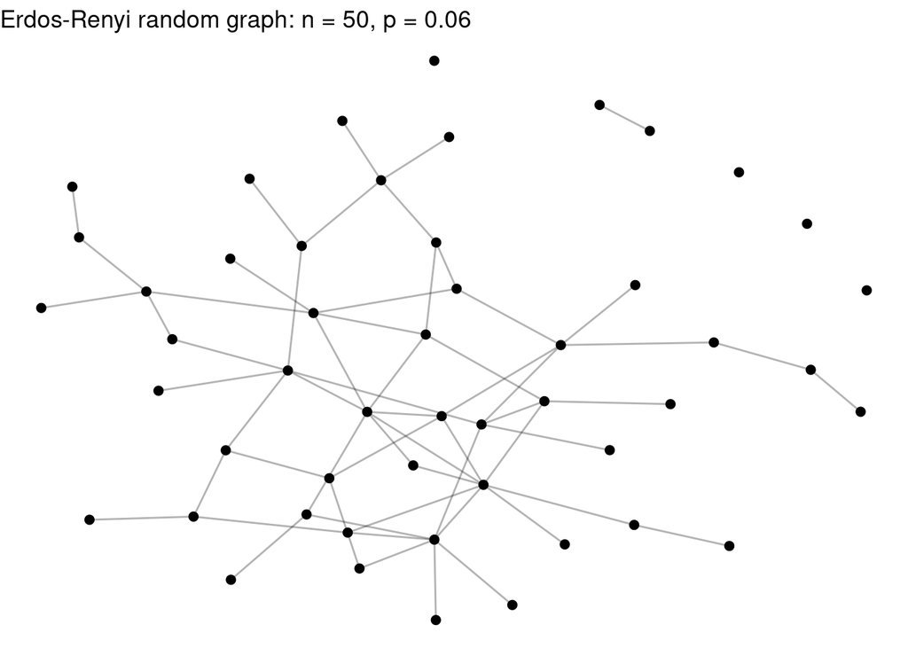

```r
set.seed(2026)
n <- 50
p <- 0.06

g_er <- play_erdos_renyi(n, p, directed = FALSE)

set.seed(1)
ggraph(g_er, layout = "fr") +
  geom_edge_link(alpha = 0.3) +
  geom_node_point(size = 2) +
  theme_void() +
  labs(title = paste0("Erdos-Renyi random graph: n = ", n, ", p = ", p))
```

### Exercise 0.1 - Solution

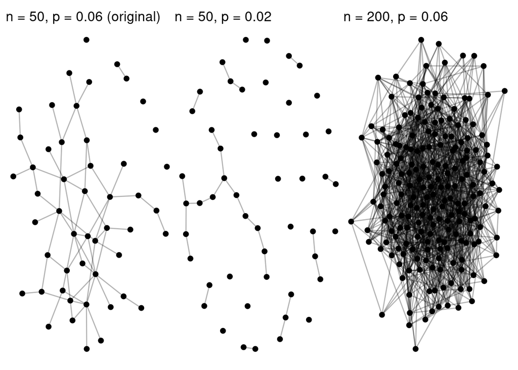

```r
# (a) same n, smaller p
set.seed(2026)
g_er_lowp <- play_erdos_renyi(n = 50, p = 0.02, directed = FALSE)

# (b) same p, larger n (as initial one)
set.seed(2026)
g_er_highn <- play_erdos_renyi(n = 200, p = 0.06, directed = FALSE)

set.seed(1)
p_base <- ggraph(g_er, layout = "fr") +
  geom_edge_link(alpha = 0.3) + geom_node_point(size = 2) +
  theme_void() + labs(title = "n = 50, p = 0.06 (original)")

set.seed(1)
p_lowp <- ggraph(g_er_lowp, layout = "fr") +
  geom_edge_link(alpha = 0.3) + geom_node_point(size = 2) +
  theme_void() + labs(title = "n = 50, p = 0.02")

set.seed(1)
p_highn <- ggraph(g_er_highn, layout = "fr") +
  geom_edge_link(alpha = 0.3) + geom_node_point(size = 2) +
  theme_void() + labs(title = "n = 200, p = 0.06")

p_base + p_lowp + p_highn
```

### 0.2 Degree distribution vs the Poisson overlay

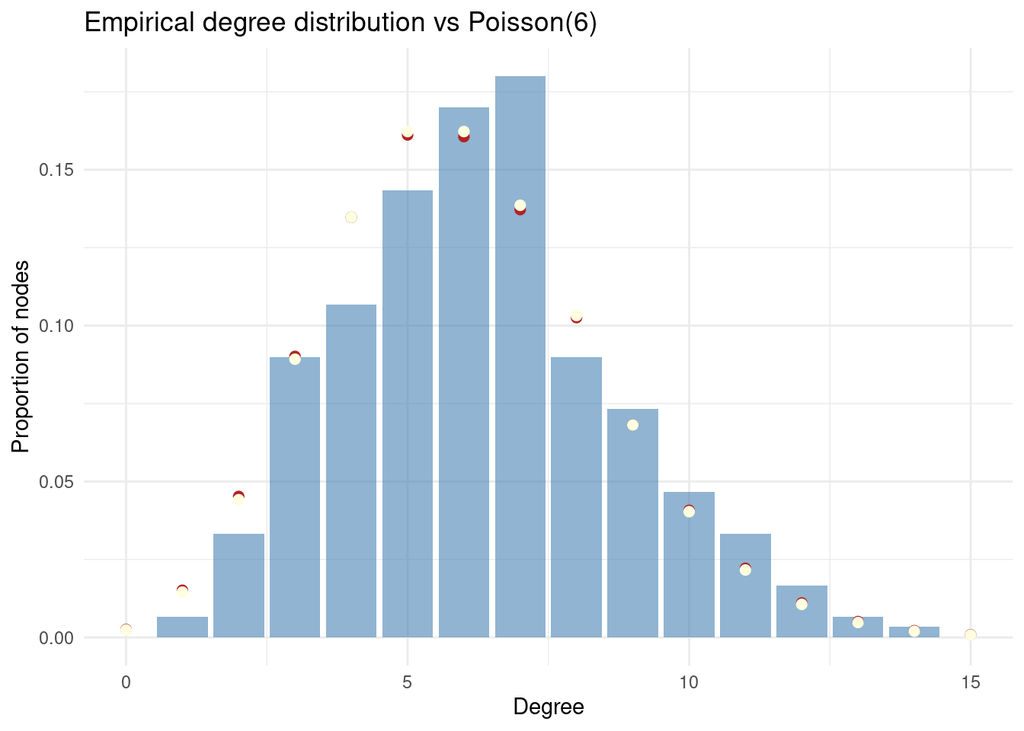

```r
set.seed(2026)
n <- 300; p <- 0.02
g_er2 <- play_erdos_renyi(n, p, directed = FALSE) |>
  activate(nodes) |> mutate(degree = centrality_degree())

deg_df <- g_er2 |> activate(nodes) |> as_tibble()
lambda <- (n - 1) * p

ggplot(deg_df, aes(degree)) +
  geom_bar(aes(y = after_stat(prop)), fill = "steelblue", alpha = 0.6) +
  geom_point(data = data.frame(degree = 0:15, prop = dpois(0:15, lambda)),
             aes(degree, prop), colour = "firebrick", size = 2) +
  geom_point(data = data.frame(degree = 0:15, prop = dbinom(0:15, size = n-1, prob = p)),
             aes(degree, prop), colour = "lightyellow", size = 2) +
  labs(title = paste0("Empirical degree distribution vs Poisson(",
                       round(lambda, 1), ")"),
       x = "Degree", y = "Proportion of nodes") +
  theme_minimal()
```

### Exercise 0.2 - Solution

Each node makes $n-1$ independent “coin flips”, i.e. one Bernoulli(`p`) trial per possible partner, deciding whether that edge exists. Its degree is just the number of “successes” out of those $n-1$ trials, i.e. Binomial$(n-1, p)$. When $n$ is large and $p$ is small (so each individual edge is rare but there are many chances), the classic Poisson limit of the binomial kicks in: the number of trials grows, the per-trial success probability shrinks, and their product $\lambda = (n-1)p$ stays roughly constant, which is exactly the regime in which Binomial$(n-1,p) \to$ Poisson$(\lambda)$. Binomial and Poisson are super-imposed above.

### Exercise 0.3 - Solution

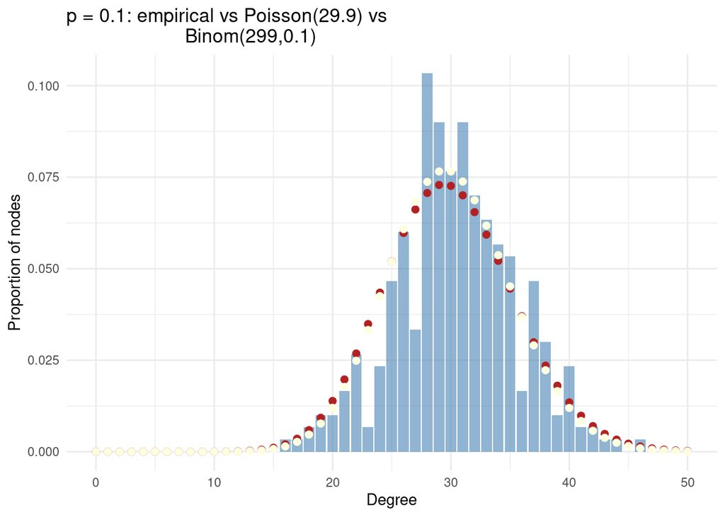

```r
set.seed(2026)
n <- 300; p <- 0.1 # Maybe even go further from "small p", e.g. 0.3
g_er3 <- play_erdos_renyi(n, p, directed = FALSE) |>
  activate(nodes) |> mutate(degree = centrality_degree())

deg_df3 <- g_er3 |> activate(nodes) |> as_tibble()
lambda3 <- (n - 1) * p

ggplot(deg_df3, aes(degree)) +
  geom_bar(aes(y = after_stat(prop)), fill = "steelblue", alpha = 0.6) +
  geom_point(data = data.frame(degree = 0:50, prop = dpois(0:50, lambda3)),
             aes(degree, prop), colour = "firebrick", size = 2) +
  geom_point(data = data.frame(degree = 0:50, prop = dbinom(0:50, size = n-1, prob = p)),
             aes(degree, prop), colour = "lightyellow", size = 2) +
  labs(title = paste0("p = 0.1: empirical vs Poisson(", round(lambda3, 1), ") vs
                      Binom(",n-1,",",p,")"), x = "Degree", y = "Proportion of nodes") +
  theme_minimal()
```

The Poisson overlay is now a noticeably worse approximation to the Bionomial. The Poisson approximation to the Binomial relies on `p` being small (so $\lambda = (n-1)p$ stays moderate while $n-1$ is large). Once `p = 0.1`, $\lambda = 29.9$ is no longer “small”, and the true distribution is Binomial$(299, 0.1)$, which is now close enough to its own mean and variance ($np$ and $np(1-p)$ diverge more from each other) that it looks more symmetric/Normal-ish than Poisson-shaped. The assumption that breaks is “$p$ small enough that $n-1$ independent rare events behave like a Poisson process”. As `p` grows, the events stop being rare, and the Binomial keeps its own (slightly narrower) variance instead of collapsing onto the Poisson’s variance-equals-mean property.

Also notice that the variability makes it not obvious that the Binomial$(299, 0.1)$ is such a good fit?!

### 0.3 A heavier-tailed alternative

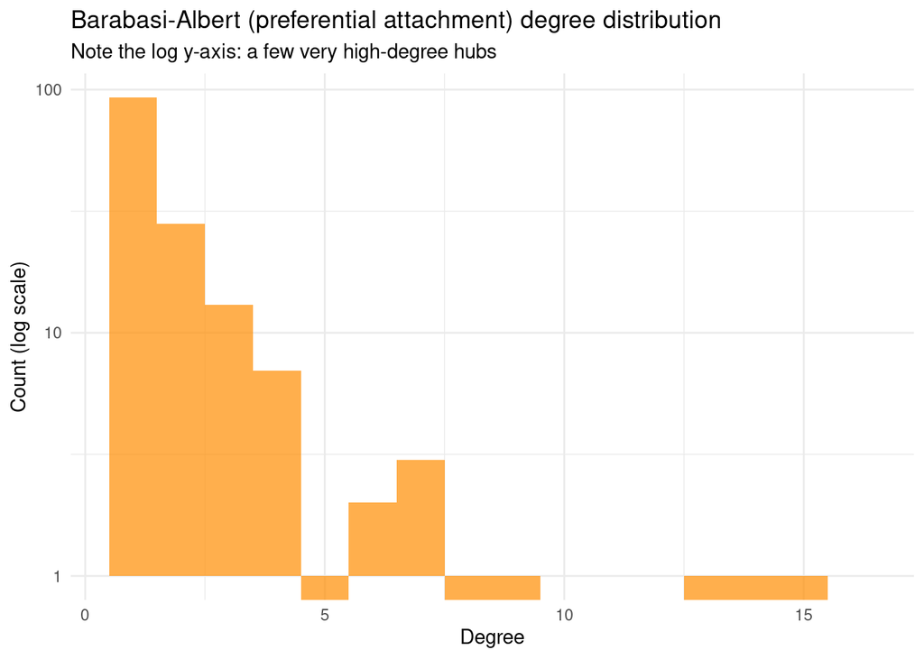

```r
set.seed(2026)
g_ba <- igraph::sample_pa(n = 150, power = 1, m = 1, directed = FALSE) |>
  as_tbl_graph() |>
  activate(nodes) |> mutate(degree = centrality_degree())

ba_df <- g_ba |> activate(nodes) |> as_tibble()

ggplot(ba_df, aes(degree)) +
  geom_histogram(binwidth = 1, fill = "darkorange", alpha = 0.7) +
  scale_y_log10() +
  labs(title = "Barabasi-Albert (preferential attachment) degree distribution",
       subtitle = "Note the log y-axis: a few very high-degree hubs",
       x = "Degree", y = "Count (log scale)") +
  theme_minimal()
```

### Exercise 0.4 - Solution

The Erdős-Rényi degree distribution is tightly clustered around its mean (Poisson-shaped, thin tails), whereas the Barabási-Albert distribution is heavy-tailed: most nodes have very low degree but a small number of “hub” nodes have degree far above the average. As a contact network for an infectious disease, the Barabási-Albert (preferential-attachment) structure is the more realistic and more concerning choice, because it implies that infection reaching a single hub can create a large number of new exposures at once — outbreaks on such networks can be driven disproportionately by a handful of highly-connected individuals (“superspreaders”), unlike the Erdős-Rényi case where every node plays a roughly similar, average-sized role in transmission.

## Tutorial 1: Building and plotting a basic network

### 1.1 A small dataset

```r
data(highschool, package = "ggraph")
head(highschool)
```

```
  from to year
1    1 14 1957
2    1 15 1957
3    1 21 1957
4    1 54 1957
5    1 55 1957
6    2 21 1957
```

```r
g <- as_tbl_graph(highschool, directed = FALSE)
g
```

```
# A tbl_graph: 70 nodes and 506 edges
#
# An undirected multigraph with 1 component
#
# Node Data: 70 × 0 (active)
#
# Edge Data: 506 × 3
   from    to  year
  <int> <int> <dbl>
1     1    13  1957
2     1    14  1957
3     1    20  1957
# ℹ 503 more rows
```

### Exercise 1.1 - Solution

```r
g |> activate(nodes) |> as_tibble()
```

```
# A tibble: 70 × 0
```

```r
g |> activate(edges) |> as_tibble()
```

```
# A tibble: 506 × 3
    from    to  year
   <int> <int> <dbl>
 1     1    13  1957
 2     1    14  1957
 3     1    20  1957
 4     1    52  1957
 5     1    53  1957
 6     2    20  1957
 7     2    21  1957
 8     3     9  1957
 9     3    14  1957
10     4     5  1957
# ℹ 496 more rows
```

```r
igraph::vcount(g)
```

```
[1] 70
```

```r
igraph::ecount(g)
```

```
[1] 506
```

```r
igraph::is_directed(g)
```

```
[1] FALSE
```

The network has 70 nodes (pupils) and around 506 edges (the exact count should match your `ecount(g)` output. It will differ slightly depending on whether the two survey years are treated as separate multi-edges or collapsed). We forced `directed = FALSE` when building `g`, so it prints as undirected, which matches the natural interpretation of “friendship” as a mutual/symmetric relationship, even though the raw `from`/`to` columns look directional, a reported friendship nomination is treated here as evidence of an undirected tie.

> **A note on repeated/reciprocal nominations.** The raw `highschool` edge list can contain more than one row for the same unordered pair of pupils. This happens two ways: (i) the same *directed* nomination is reported in both survey waves (e.g. pupil 4 names pupil 5 in both 1957 and 1958), or (ii) the nomination is *reciprocated* within a single wave (4 names 5 **and** 5 names 4 that same year). Because `g` is built directly from this un-aggregated 506-row list with `as_tbl_graph(..., directed = FALSE)`, every one of those rows becomes its own undirected edge. `g` is technically a **multigraph**, with some pairs of pupils joined by more than one parallel edge. This has two consequences worth flagging, since they resurface in Section 2.4 (edge weights) and in the degree-based exercises (2.1 & 2.2, 3.4, 3.6): `ecount(g)` counts *nomination events*, not distinct friendships, and **degree inherits this > automatically**, since each parallel edge is counted separately.

### 1.2 Moving between representations

```r
adj <- igraph::as_adjacency_matrix(g, sparse = FALSE)
adj[1:6, 1:6]
```

```
     [,1] [,2] [,3] [,4] [,5] [,6]
[1,]    0    0    0    0    0    0
[2,]    0    0    0    0    0    0
[3,]    0    0    0    0    0    0
[4,]    0    0    0    0    3    0
[5,]    0    0    0    3    0    0
[6,]    0    0    0    0    0    0
```

### Exercise 1.2 — Solution

```r
edges_tbl <- g |> activate(edges) |> as_tibble()

# pick a connected pair directly from the adjacency matrix
pair <- which(adj[1:6, 1:6] > 0, arr.ind = TRUE)[1, ]
i <- pair["row"]; j <- pair["col"]
c(i, j)
```

```
row col
  5   4
```

```r
# confirm the same pair appears in the edge list (in either direction,
# since the graph is undirected)
edges_tbl |> filter((from == i & to == j) | (from == j & to == i))
```

```
# A tibble: 3 × 3
   from    to  year
  <int> <int> <dbl>
1     4     5  1957
2     4     5  1958
3     4     5  1958
```

```r
which(adj[i,]>0)
```

```
[1]  4 12 18 25 41
```

```r
which(adj[,i]>0)
```

```
[1]  4 12 18 25 41
```

Both representations do carry the same information: a `1` in `adj[i, j]` corresponds to a row in the edge tibble linking nodes `i` and `j` (in one order or the other, since the graph is undirected).

### 1.3 A default plot

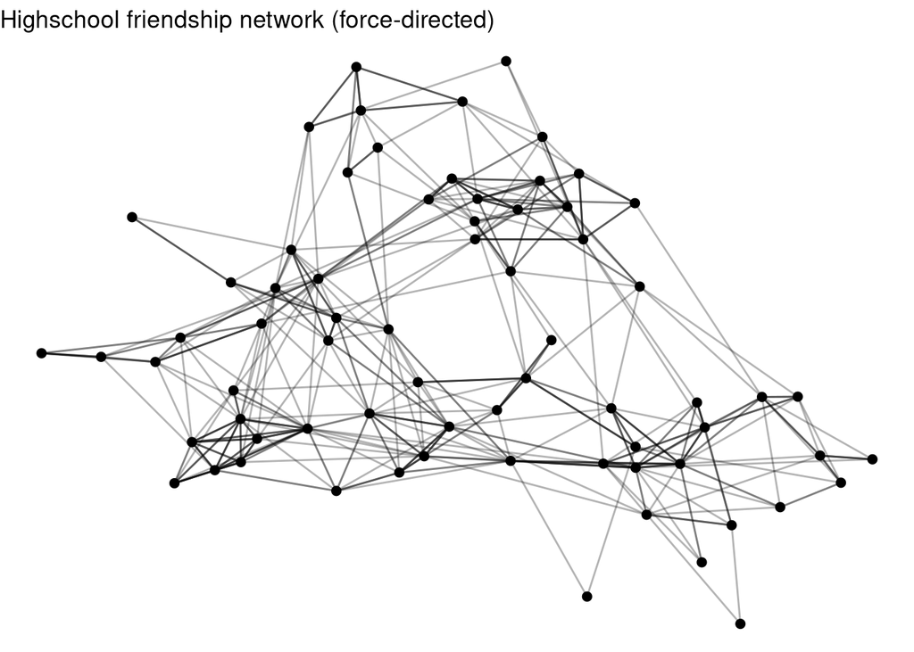

```r
set.seed(1)
ggraph(g, layout = "fr") +
  geom_edge_link(alpha = 0.3) +
  geom_node_point(size = 2) +
  theme_void() +
  labs(title = "Highschool friendship network (force-directed)")
```

### 1.4 Trying different layouts

### Exercise 1.3 - Solution

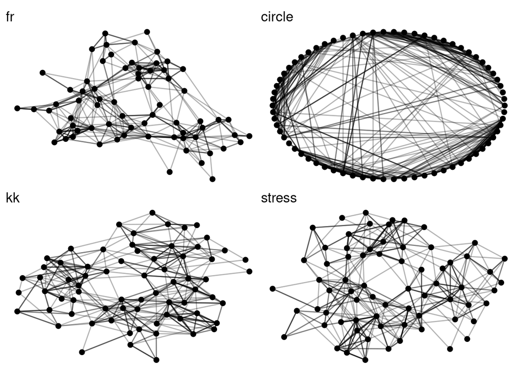

```r
set.seed(1)
p_fr <- ggraph(g, layout = "fr") +
  geom_edge_link(alpha = 0.3) + geom_node_point(size = 2) +
  theme_void() + labs(title = "fr")

p_circle <- ggraph(g, layout = "circle") +
  geom_edge_link(alpha = 0.3) + geom_node_point(size = 2) +
  theme_void() + labs(title = "circle")

set.seed(1)
p_kk <- ggraph(g, layout = "kk") +
  geom_edge_link(alpha = 0.3) + geom_node_point(size = 2) +
  theme_void() + labs(title = "kk")

set.seed(1)
p_stress <- ggraph(g, layout = "stress") +
  geom_edge_link(alpha = 0.3) + geom_node_point(size = 2) +
  theme_void() + labs(title = "stress")

(p_fr + p_circle) / (p_kk + p_stress)
```

> **Reproducibility checkpoint**: seed `1` was used before every stochastic layout call above (`fr`, `kk`, `stress`); `circle` is deterministic so no seed is needed for it.
- **`fr`** (Fruchterman-Reingold, force-directed): pulls connected nodes together and pushes unconnected ones apart, so loosely-connected clusters and peripheral/isolated nodes become visually obvious.
- **`circle`**: places every node on a circle in a fixed order, which makes node *count* and overall edge *density* easy to eyeball but destroys almost all cluster structure (everything looks like a dense tangle across the circle).
- **`kk`** (Kamada-Kawai): another force-directed method, similar in spirit to `fr` but based on graph-theoretic distances — it tends to produce a very similar overall shape to `fr` here, showing the same loosely-separated groups.
- **`stress`**: a modern stress-majorisation layout that in practice gives one of the cleanest, least-overlapping pictures. The same cluster/bridge structure as `fr`/`kk` is visible but with less node overplotting.

### 1.5 Summary statistics beyond degree

```r
tibble::tibble(
  density        = igraph::edge_density(g),
  n_nodes        = igraph::vcount(g),
  n_edges        = igraph::ecount(g),
  transitivity   = igraph::transitivity(g, type = "global"),
  ave_shortest_p = igraph::average.path.length(g)
)
```

```
# A tibble: 1 × 5
  density n_nodes n_edges transitivity ave_shortest_p
    <dbl>   <dbl>   <dbl>        <dbl>          <dbl>
1   0.210      70     506        0.404           2.64
```

> **Why `transitivity` instead of `components`?** (as in the initial sheet) A raw count of connected components is rarely very informative for a real friendship network like this one: it typically resolves to “one giant component plus a handful of isolates/pairs,” a single number that doesn’t say much about *how* the network is structured. **Transitivity** (the global clustering coefficient) is a more interesting complement to average shortest path: it asks “if A and B are friends, and B and C are friends, how often are A and C *also* friends?”, i.e. how much the network’s ties close into triangles. These two quantities are exactly the pair Watts & Strogatz used to define a “small-world” network.

> **Why `igraph::` and not `dplyr::summarise()`?** It’s tempting to reach for `g |> activate(nodes) |> summarise(...)` here since that’s the verb Weeks 1-6 trained us to use. But `tidygraph` doesn’t ship a `summarise.tbl_graph` method for whole-graph statistics like these. `summarise()` is designed to collapse *node* or *edge* attribute columns, not to call graph-level functions like `edge_density()` or `components()`. If `tidygraph` isn’t fully attached in a fresh R session, this can fail silently or with a `no applicable method for 'summarise'` error depending on dispatch order. Calling the `igraph::` functions directly on `g` sidesteps the issue entirely: a `tbl_graph` *is* an `igraph` object underneath, so every `igraph::` function works on it without going through `tidygraph`’s dplyr verbs at all.

### Exercise 1.4 - Solution

```r
set.seed(2026)
n_hs <- igraph::vcount(g)
d_hs <- igraph::edge_density(g)
g_er_compare <- play_erdos_renyi(n_hs, p = d_hs, directed = FALSE)

tibble::tibble(
  network      = c("highschool", "ER(same n, same d as hs)"),
  density      = c(igraph::edge_density(g), igraph::edge_density(g_er_compare)),
  n_nodes      = c(igraph::vcount(g), igraph::vcount(g_er_compare)),
  n_edges      = c(igraph::ecount(g), igraph::ecount(g_er_compare)),
  transitivity = c(igraph::transitivity(g, type = "global"),
                    igraph::transitivity(g_er_compare, type = "global")),
  short_path   = c(igraph::average.path.length(g), igraph::average.path.length(g_er_compare))
)
```

```
# A tibble: 2 × 6
  network                  density n_nodes n_edges transitivity short_path
  <chr>                      <dbl>   <dbl>   <dbl>        <dbl>      <dbl>
1 highschool                 0.210      70     506        0.404       2.64
2 ER(same n, same d as hs)   0.204      70     493        0.212       1.85
```

The two statistics tell different parts of the story, and it’s worth reporting both rather than picking a single “winner”:

Together, **short average path length *and* high transitivity** is precisely the “small-world” signature (Watts & Strogatz, 1998): it is the *combination*, not either statistic alone, that distinguishes real social networks from purely random graphs of matched size and density. Also see the multigraph note in Exercise 1.1: `transitivity()` and `average.path.length()` are both computed on the raw multigraph `g`, so if you want a “distinct friends only” version of these statistics for comparison, simplify first with `igraph::simplify(g)` (which drops parallel edges and self-loops) and re-run the same table. Because `play_erdos_renyi()` is itself stochastic, it’s also worth re-running the ER side of the comparison over several seeds (or several `replicate()`s) rather than trusting a single draw . The *qualitative* direction of the gap should be stable, but the exact numbers will jitter from run to run.

## Tutorial 2: Encoding attributes

### 2.1 Computing node attributes

```r
g2 <- g |>
  activate(nodes) |>
  mutate(
    degree = centrality_degree(),
    component = as.factor(group_components())
  )

g2 |> activate(nodes) |> as_tibble() |> head()
```

```
# A tibble: 6 × 2
  degree component
   <dbl> <fct>
1     10 1
2      4 1
3      2 1
4     13 1
5     10 1
6     10 1
```

### 2.2 Encoding degree as size and colour

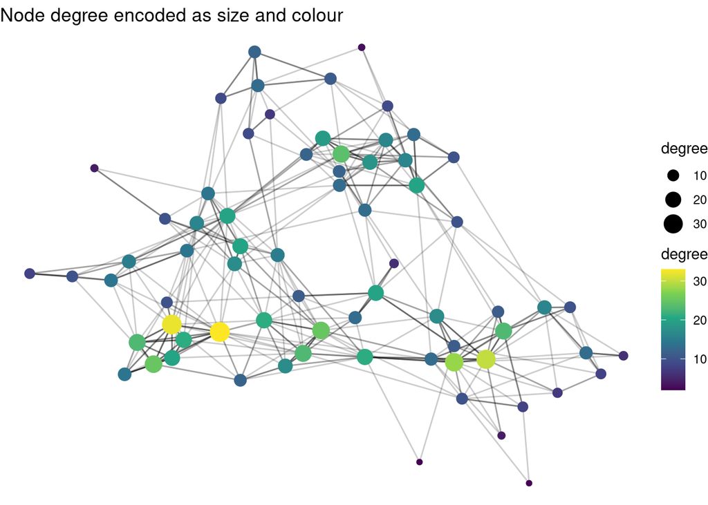

```r
set.seed(1)
ggraph(g2, layout = "fr") +
  geom_edge_link(alpha = 0.2) +
  geom_node_point(aes(size = degree, colour = degree)) +
  scale_colour_viridis_c() +
  scale_size_area(max_size = 6) +
  theme_void() +
  labs(title = "Node degree encoded as size and colour")
```

### Exercise 2.1 - Solution

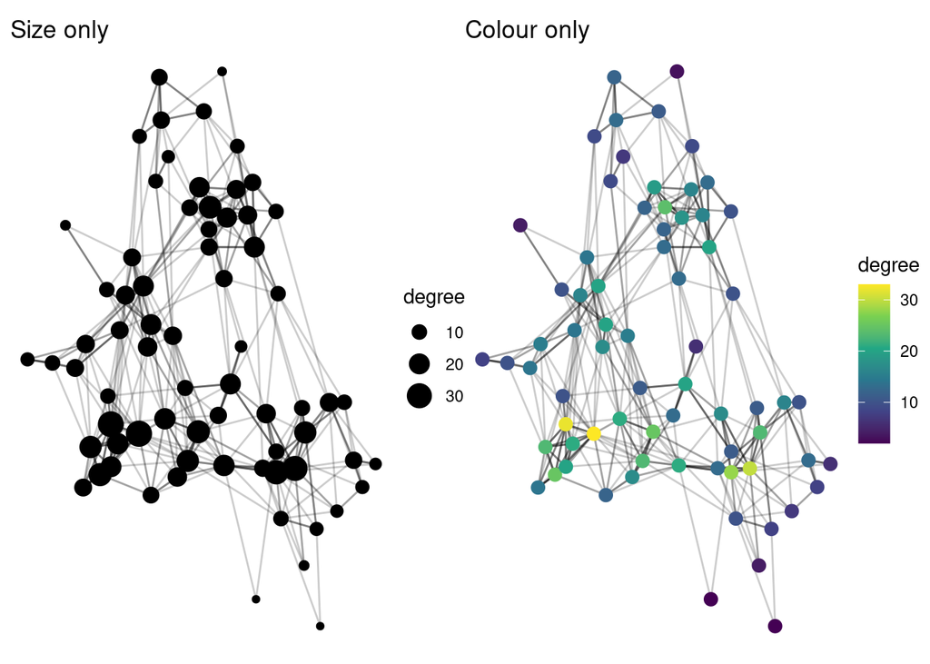

```r
set.seed(1)
p_size <- ggraph(g2, layout = "fr") +
  geom_edge_link(alpha = 0.2) +
  geom_node_point(aes(size = degree)) +
  scale_size_area(max_size = 6) +
  theme_void() + labs(title = "Size only")

set.seed(1)
p_colour <- ggraph(g2, layout = "fr") +
  geom_edge_link(alpha = 0.2) +
  geom_node_point(aes(colour = degree), size = 3) +
  scale_colour_viridis_c() +
  theme_void() + labs(title = "Colour only")

p_size + p_colour
```

The redundant size+colour encoding is not really necessary: size alone already communicates degree ordering well, and colour alone (with `viridis`, which is perceptually uniform and colour-blind-safe) does the same job. Combining them mainly helps when node markers are small or heavily overplotted, where colour is easier to pick out than a subtle size difference. For a colour-blind reader the answer strengthens in favour of redundancy: a **red-green** palette would be unreadable to the most common form of colour-blindness, so keeping **size** as a second, colour-independent channel becomes actively useful insurance. `scale_colour_viridis_c()`, not a red-green scale, is the safer defaultm even when size is present too.

### 2.3 A second centrality measure

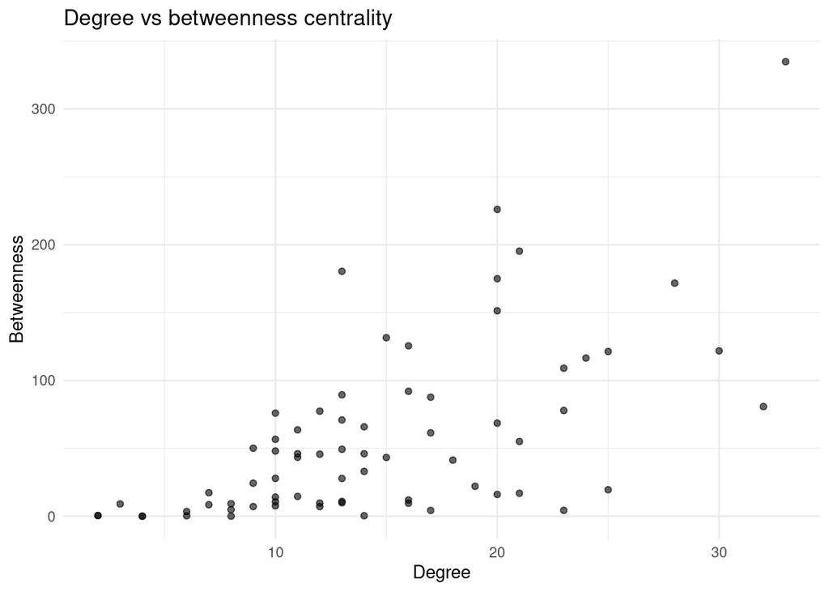

```r
g2 <- g2 |>
  mutate(betweenness = centrality_betweenness())

g2 |> activate(nodes) |> as_tibble() |>
  ggplot(aes(degree, betweenness)) +
  geom_point(alpha = 0.6) +
  labs(title = "Degree vs betweenness centrality",
       x = "Degree", y = "Betweenness") +
  theme_minimal()
```

### Exercise 2.2 - Solution

```r
g2 |> activate(nodes) |> as_tibble() |>
  filter(degree <= median(degree)) |>
  arrange(desc(betweenness)) |>
  head(5)
```

```
# A tibble: 5 × 3
  degree component betweenness
   <dbl> <fct>           <dbl>
1     13 1               180.
2     13 1                89.4
3     12 1                77.4
4     10 1                75.9
5     13 1                70.9
```

Betweenness measures how often a node sits on the shortest path between some *other* pair of nodes: for every pair of nodes in the network, we look at all their shortest path(s) and ask what fraction of those paths pass through our node of interest, then sum that fraction over every pair. A node scores high on betweenness not by having many friends itself, but by being the connector that many *other* pairs’ shortest routes have to go through.

Pupils with high betweenness but only moderate degree sit on the shortest paths between otherwise-separate friend groups without necessarily having many friends themselves. They act as **bridges** or “gatekeepers” connecting clusters, rather than being broadly popular hubs. For epidemic control, the high-betweenness/moderate-degree node is often the more strategic one to vaccinate first: removing a bridge can cut off transmission between whole clusters, whereas removing a high-degree-but-low-betweenness “popular within one clique” node mainly protects that one clique locally and does less to stop the disease from jumping between separate parts of the network.

### 2.4 Edge attributes: worked examples

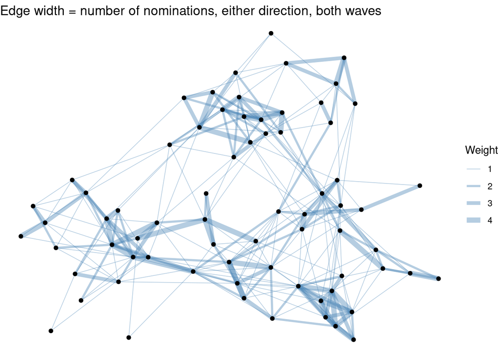

```r
# Symmetrise the pair *before* counting. Naively doing
# count(from, to) groups by the ORDERED pair, so a nomination reported
# as 4 -> 5 and a reciprocal nomination reported as 5 -> 4 are treated
# as two different pairs and end up on two separate (parallel) edges
# instead of contributing to one edge's weight. pmin()/pmax() collapse
# {4,5} and {5,4} onto the same unordered pair first.
edge_weights <- highschool |>
  mutate(pupil_a = pmin(from, to), pupil_b = pmax(from, to)) |>
  count(pupil_a, pupil_b, name = "weight") |>
  rename(from = pupil_a, to = pupil_b)

g_w <- as_tbl_graph(edge_weights, directed = FALSE)

set.seed(1)
ggraph(g_w, layout = "fr") +
  geom_edge_link(aes(width = weight), alpha = 0.4, colour = "steelblue") +
  scale_edge_width(range = c(0.3, 2.5)) +
  geom_node_point(size = 1.5) +
  theme_void() +
  labs(title = "Edge width = number of nominations, either direction, both waves",
       edge_width = "Weight")
```

> **Does a repeated/reciprocated relationship show up in the weight?** Only if the pair is symmetrised first, as above. Take pupils 4 and 5 as an example: suppose the raw data has one nomination between them in 1957 and two in 1958 (i.e. that year both `4 → 5` *and* `5 → 4` were reported). The naive `count(from, to, name = "weight")` groups by the *ordered* pair, so it reports `4→5` with weight 2 (the two same-direction nominations, one per wave) and `5→4` with weight 1 (the single reciprocal nomination) as **two separate rows**, which become two separate parallel edges once fed into `as_tbl_graph()`. `geom_edge_link()` draws both as straight lines between the same two points, so they overplot exactly and *look* like one ordinary edge on screen. The true combined strength of the relationship (3 nominations out of a possible 4: two waves × two directions) never reaches the width encoding at all. The symmetrised version above folds both directions into one unordered pair first, so this pair correctly reports a single edge with `weight = 3`.

> **Is this accounted for in degree?** Yes, automatically. And this is the flip side of the multigraph note in Exercise 1.1. `g` is built from the *raw, un-aggregated* edge list, so every nomination (both directions, both waves) is kept as its own parallel edge, and `centrality_degree()`/`igraph::degree()` counts parallel edges separately. So a reciprocated or twice-reported pair contributes 2 or more to each pupil’s degree, not 1 — degree throughout this tutorial effectively means “how many nomination events this pupil is part of,” not “how many distinct pupils they’re connected to.” That’s a reasonable definition for a friendship-strength analysis, but it’s a different definition than “distinct friend count,” and it’s worth being explicit about which one you mean. If you want the latter, compute degree on a **simplified** graph instead (`igraph::degree(igraph::simplify(g))`) or on `g_w` above, which has already collapsed each pair down to a single weighted edge.

> **Does it matter?** Well maybe. It depends if you want to count the friendship relationships in each year “only” or if you want to count the nominations between pairs along the two years (e.g. during PE in 1957, during the ball at the end of 1957 and again in the Maths class in 1958).

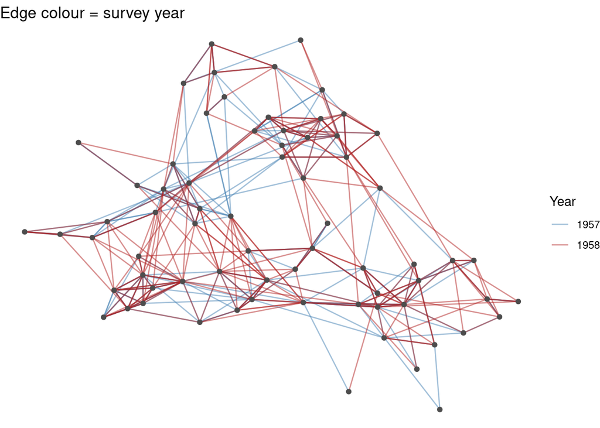

```r
g_year <- as_tbl_graph(highschool, directed = FALSE)

set.seed(1)
ggraph(g_year, layout = "fr") +
  geom_edge_link(aes(colour = factor(year)), alpha = 0.5) +
  geom_node_point(size = 1.5, colour = "grey30") +
  scale_edge_colour_manual(values = c("steelblue", "firebrick")) +
  theme_void() +
  labs(title = "Edge colour = survey year", edge_colour = "Year")
```

### Exercise 2.3 - Solution

**(a) Uncapped width scale**

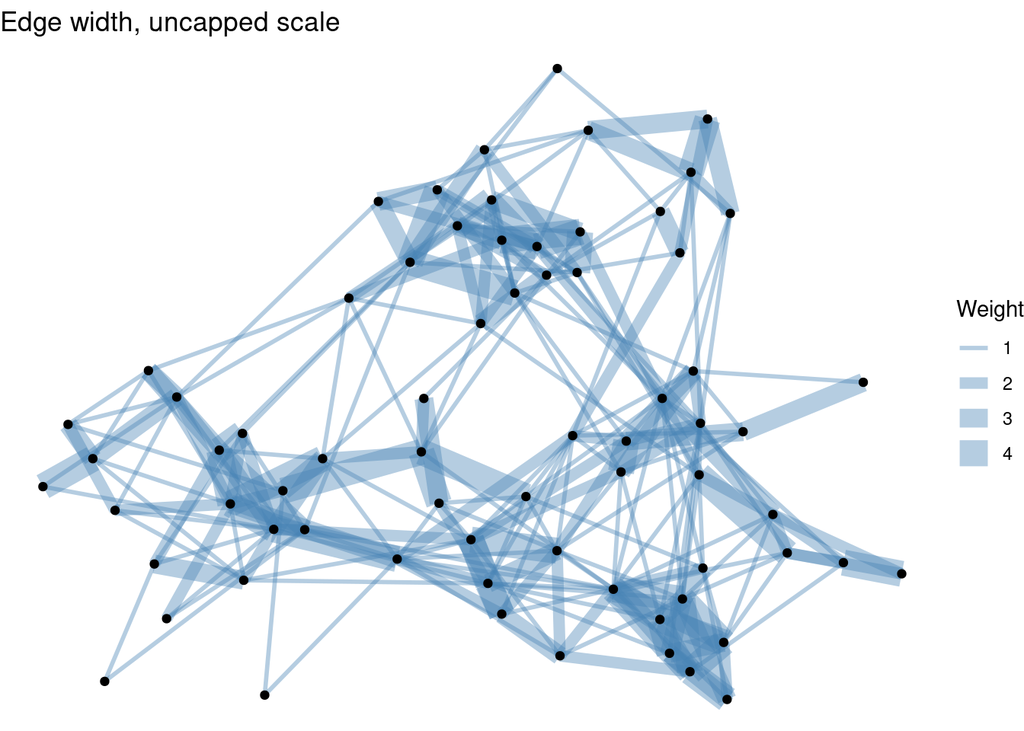

```r
set.seed(1)
ggraph(g_w, layout = "fr") +
  geom_edge_link(aes(width = weight), alpha = 0.4, colour = "steelblue") +
  geom_node_point(size = 1.5) +
  theme_void() +
  labs(title = "Edge width, uncapped scale", edge_width = "Weight")
```

Without `scale_edge_width(range = ...)`, ggraph maps the full range of weights onto a much wider default pixel range. With the symmetrised `weight` from Section 2.4, a pair of pupils can score anywhere from 1 up to 4 (two survey waves × two possible directions), so the ratio between the least- and most-nominated pairs is small in the data (at most 4x) but ggplot’s default line-width range is comparatively large. The uncapped version visually overstates the difference, making a weight-4 edge look many times more dramatic than a weight-1 edge rather than the modest 4x the data actually supports. `scale_edge_width(range = c(0.3, 2.5))` compresses that back down to a pixel-width ratio that better matches the true ratio in the underlying counts.

**(b) Year as alpha**

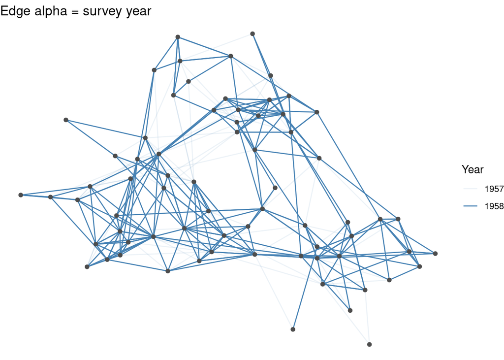

```r
set.seed(1)
ggraph(g_year, layout = "fr") +
  geom_edge_link(aes(alpha = factor(year)), colour = "steelblue") +
  geom_node_point(size = 1.5, colour = "grey30") +
  theme_void() +
  labs(title = "Edge alpha = survey year", edge_alpha = "Year")
```

Alpha is a weaker substitute here: it does distinguish the two years somewhat, but because alpha also naturally reads as “importance” or “confidence” rather than “category”, it risks implying that one year’s friendships are less real or less certain than the other’s, rather than simply different. Colour keeps the two years visually equal in weight while still being distinguishable, which better matches the fact that 1957 and 1958 are just two unordered categories, not a more/less scale.

**(c)** Left as a template for your own dataset. The key design decision to document is which channel (width vs colour vs alpha) matches whether your own edge attribute is **continuous/ordered** (width or colour gradient) or **categorical** (colour or shape), following the principle demonstrated above.

### 2.5 Applying course styling

### Exercise 2.4 - Solution

Applying a custom theme (fonts, palette) on top of a network plot typically means starting from `theme_void()` (to remove the axes/grid that don’t mean anything for node-link layouts) and then re-adding just the elements your course theme controls: title font, colour palette for `scale_colour_*`, and legend styling, via `theme_void() + theme(plot.title = ..., legend.position = ...)` rather than starting from your course’s usual `theme_minimal()`-based theme. The common friction point is exactly the one hinted at in the question: if your course theme sets `axis.text`/`axis.title` elements, those settings become irrelevant (there are no meaningful axes on a node-link plot) and can safely be dropped or ignored for this plot type, while colour-palette and font settings from the same theme can still be reused directly.

## Tutorial 3 (double session): Alternatives to node-link diagrams, and uncertainty about network statistics

### Short session: Adjacency matrix view

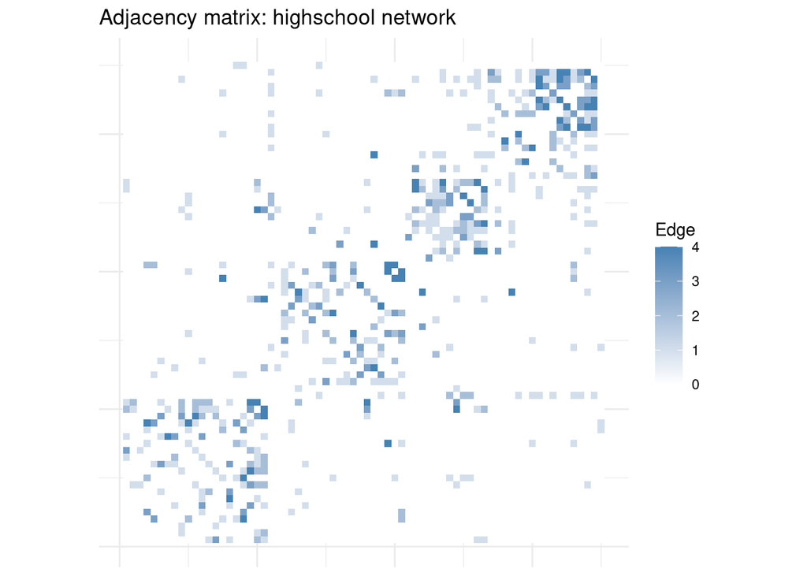

```r
library(reshape2)

adj <- as.matrix(igraph::as_adjacency_matrix(g))
adj_df <- melt(adj)

ggplot(adj_df, aes(Var1, Var2, fill = value)) +
  geom_tile() +
  scale_fill_gradient(low = "white", high = "steelblue") +
  coord_equal() +
  theme_minimal() +
  theme(axis.text = element_blank()) +
  labs(title = "Adjacency matrix: highschool network",
       x = NULL, y = NULL, fill = "Edge")
```

### Exercise 3.1 - Solution

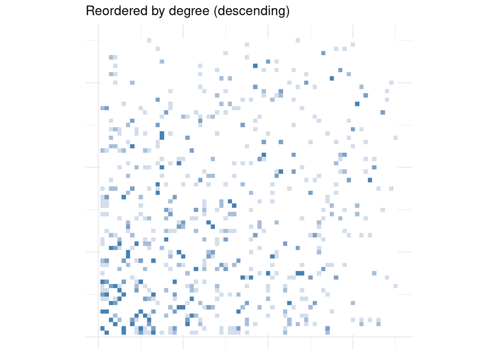

```r
node_order_degree <- g2 |> activate(nodes) |> as_tibble() |>
  mutate(node_id = row_number()) |>
  arrange(desc(degree)) |>
  pull(node_id)

adj_reordered_deg <- adj[node_order_degree, node_order_degree]
adj_df_reordered_deg <- melt(adj_reordered_deg)

p_by_degree <- ggplot(adj_df_reordered_deg, aes(Var1, Var2, fill = value)) +
  geom_tile() +
  scale_fill_gradient(low = "white", high = "steelblue") +
  coord_equal() +
  theme_minimal() +
  theme(axis.text = element_blank(), legend.position = "none") +
  labs(title = "Reordered by degree (descending)", x = NULL, y = NULL, fill = "Edge")

p_by_degree
```

### Long session (after break)

#### Arc diagram

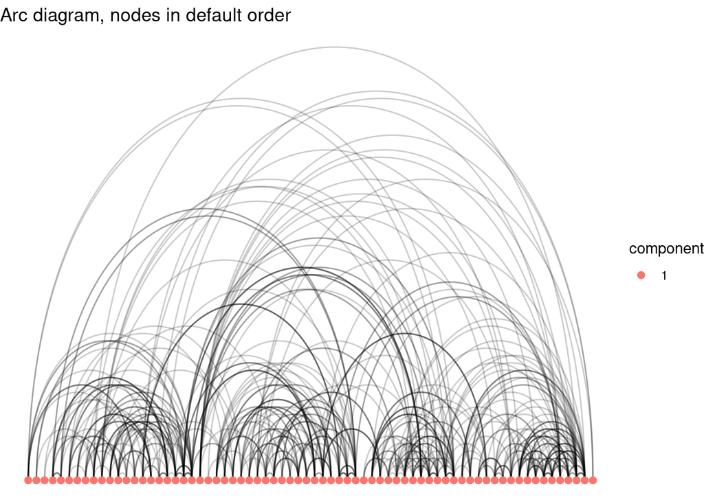

```r
set.seed(1)
ggraph(g2, layout = "linear") +
  geom_edge_arc(alpha = 0.2) +
  geom_node_point(aes(colour = component), size = 2) +
  theme_void() +
  labs(title = "Arc diagram, nodes in default order")
```

### Exercise 3.2 - Solution

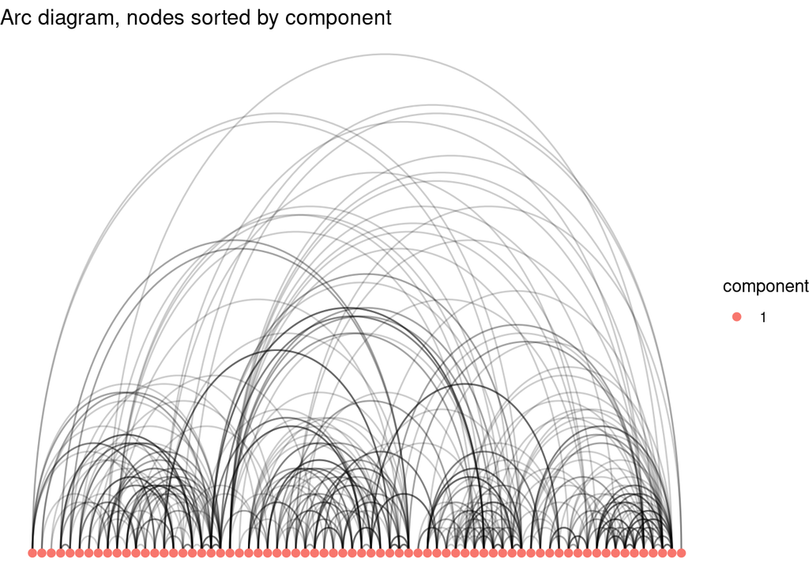

```r
g2_sorted <- g2 |>
  activate(nodes) |>
  mutate(node_id = row_number()) |>
  arrange(component)

set.seed(1)
ggraph(g2_sorted, layout = "linear") +
  geom_edge_arc(alpha = 0.2) +
  geom_node_point(aes(colour = component), size = 2) +
  theme_void() +
  labs(title = "Arc diagram, nodes sorted by component")
```

### Exercise 3.3 - Solution

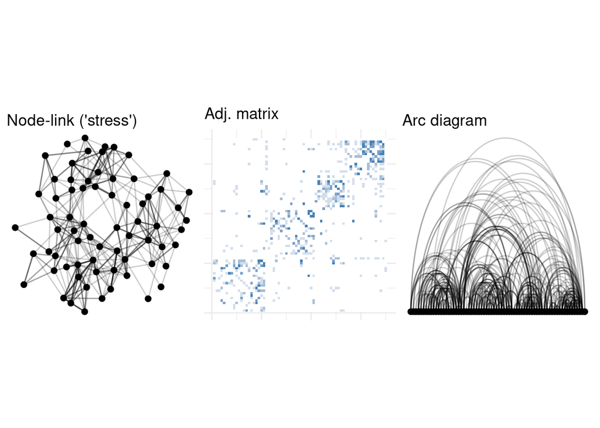

```r
set.seed(1)
p_nodelink <- ggraph(g2, layout = "stress") +
  geom_edge_link(alpha = 0.2) +
  geom_node_point(size = 2) +
  theme_void() + labs(title = "Node-link ('stress')")

p_matrix <- ggplot(adj_df, aes(Var1, Var2, fill = value)) +
  geom_tile() +
  scale_fill_gradient(low = "white", high = "steelblue") +
  coord_equal() + theme_minimal() +
  theme(axis.text = element_blank(), legend.position = "none") +
  labs(title = "Adj. matrix", x = NULL, y = NULL)

set.seed(1)
p_arc <- ggraph(g2, layout = "linear") +
  geom_edge_arc(alpha = 0.2) +
  geom_node_point(size = 2) +
  theme_void() + labs(title = "Arc diagram")

p_nodelink + p_matrix + p_arc
```

**Structured comparison (~200 words).** For showing **overall network density**, the adjacency matrix wins: every possible pair of nodes has a fixed, dedicated cell, so the proportion of coloured cells is a direct, un-distorted visual estimate of edge density. This is something node-link and arc diagrams struggle with, because line overplotting makes dense networks look like an undifferentiated smear regardless of true density. For showing **community/cluster structure**, the node-link diagram (force- or stress-based layout) is generally strongest, since spatial proximity is itself an encoding of connectedness. Clusters visually separate into distinct blobs. The reordered adjacency matrix is a close second (clusters appear as blocks along the diagonal), while the arc diagram mainly shows *whether* nodes in the same neighbourhood are adjacent under the chosen ordering rather than revealing clusters directly. For an audience **unfamiliar with network diagrams**, the node-link diagram is the best choice: it requires no explanation of “reading a matrix” or “reading nested arcs,” and its use of physical proximity for closeness matches people’s everyday intuition about “groups of friends,” even though (per Kolaczyk & Csárdi, and standard data-visualisation-handbook guidance) node-link layouts can be misleading for genuinely large or dense networks, where matrix views scale much better.

### Bridge from Week 6: a network statistic is a point estimate too

#### 3.4 Bootstrapping the mean degree

```r
set.seed(2026)
boot_mean_degree <- function(g) {
  nodes_tbl <- g |> activate(nodes) |> as_tibble()
  n <- nrow(nodes_tbl)
  resampled <- sample(seq_len(n), n, replace = TRUE)
  sub <- igraph::induced_subgraph(g, unique(resampled))
  mean(igraph::degree(sub))
}

boot_dist <- replicate(500, boot_mean_degree(g))
head(boot_dist)
```

```
[1] 10.844444  9.395349  8.936170  9.043478  9.000000 10.583333
```

### Exercise 3.4 - Solution

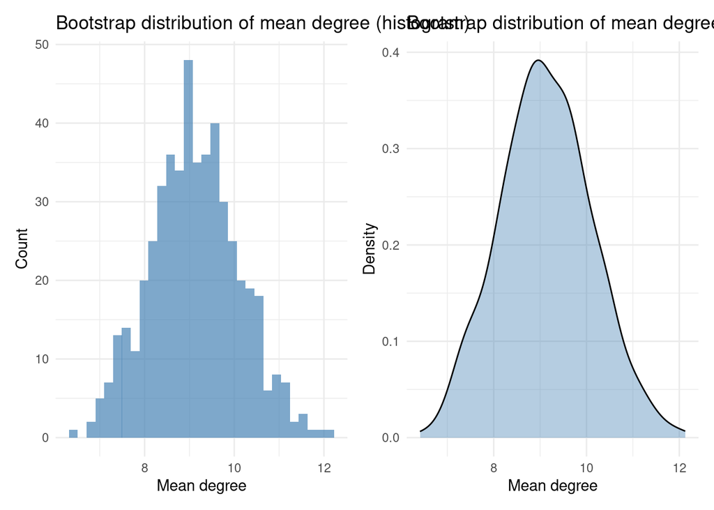

```r
p_hist <- ggplot(data.frame(x = boot_dist), aes(x)) +
  geom_histogram(bins = 30, fill = "steelblue", alpha = 0.7) +
  labs(title = "Bootstrap distribution of mean degree (histogram)",
       x = "Mean degree", y = "Count") +
  theme_minimal()

p_dens <- ggplot(data.frame(x = boot_dist), aes(x)) +
  geom_density(fill = "steelblue", alpha = 0.4) +
  labs(title = "Bootstrap distribution of mean degree (density)",
       x = "Mean degree", y = "Density") +
  theme_minimal()

p_hist + p_dens
```

```r
quantile(boot_dist, c(0.05, 0.95))
```

```
       5%       95%
 7.462971 10.784681
```

The 90% bootstrap interval reported by `quantile(boot_dist, c(0.05, 0.95))` means: if we repeated this “resample nodes with replacement, take the induced subgraph, compute mean degree” procedure many times, about 90% of the resulting mean-degree estimates would fall within the reported range.

#### 3.5 Don’t dynamite-plot it

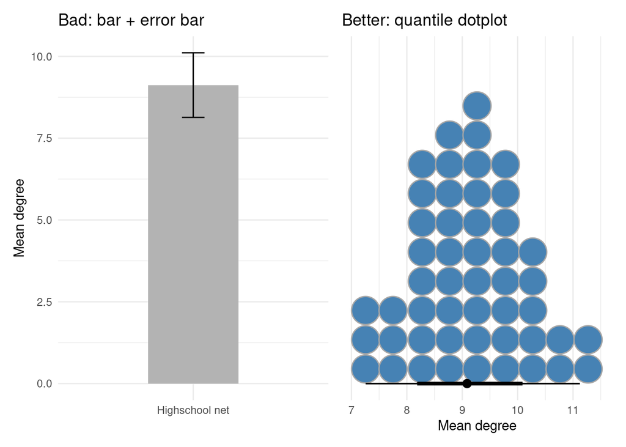

```r
summ <- data.frame(mean = mean(boot_dist), se = sd(boot_dist))

p_dynamite <- ggplot(summ, aes(x = "Highschool net", y = mean)) +
  geom_col(fill = "grey70", width = 0.4) +
  geom_errorbar(aes(ymin = mean - se, ymax = mean + se), width = 0.1) +
  labs(title = "Bad: bar + error bar", x = NULL, y = "Mean degree") +
  theme_minimal()

p_dots <- ggplot(data.frame(x = boot_dist), aes(x)) +
  ggdist::stat_dotsinterval(quantiles = 50, fill = "steelblue") +
  scale_y_continuous(NULL, breaks = NULL) +
  labs(title = "Better: quantile dotplot", x = "Mean degree") +
  theme_minimal()

p_dynamite + p_dots
```

### Exercise 3.5 - Solution

#### 3.6 Comparing degree distributions across node types (violin)

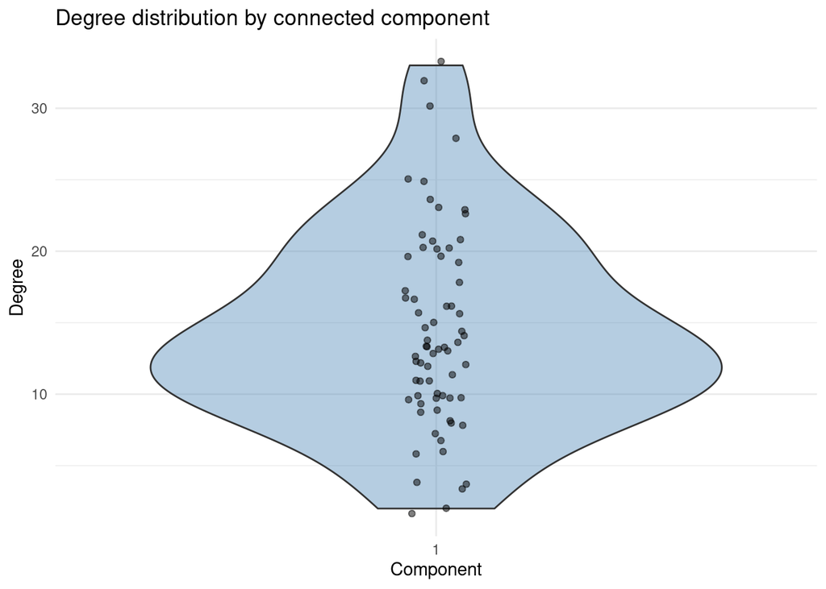

```r
g2 |> activate(nodes) |> as_tibble() |>
  ggplot(aes(component, degree)) +
  geom_violin(fill = "steelblue", alpha = 0.4) +
  geom_jitter(width = 0.05, alpha = 0.5) +
  labs(title = "Degree distribution by connected component",
       x = "Component", y = "Degree") +
  theme_minimal()
```

### Exercise 3.6 - Solution

Yes. We see a right-skewed violin (a mix of many low-degree pupils and a few well-connected ones). If they existed, small isolated components (pairs or small groups of mutually-connected pupils with no ties to the rest of the network) would show a narrow, low-degree violin, since their members can only be connected to the few other nodes in their own tiny component. A bar-plus-error-bar summary would only have shown each component’s mean degree and a symmetric spread around it. It would completely miss the *shape* (skew), which is exactly the kind of detail the violin/jitter combination is designed to surface, echoing Week 6’s general “show the distribution, not just its mean” principle applied here to a network context.

## Tutorial 4 (optional extension): A first taste of spread on a network

### 4.1 A branching process, constrained by structure

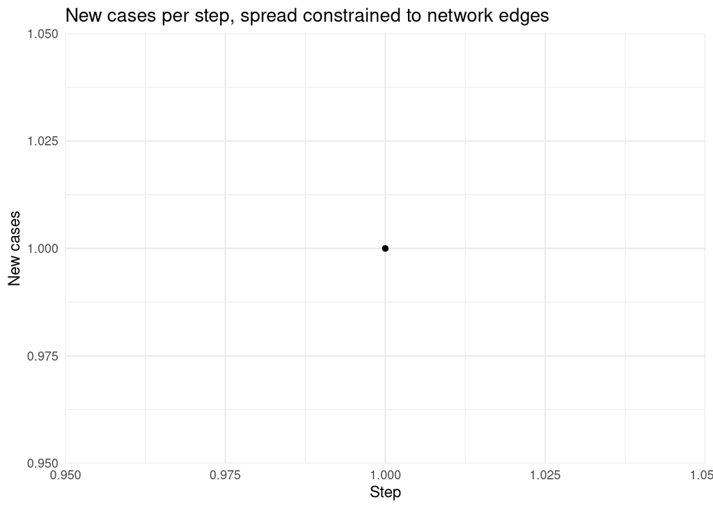

```r
set.seed(2026)
n <- 60
g_contact <- play_erdos_renyi(n, p = 0.06, directed = FALSE)
adj <- as.matrix(igraph::as_adjacency_matrix(g_contact))

simulate_on_network <- function(adj, p_infect = 0.3, max_steps = 15) {
  n <- nrow(adj)
  infected <- rep(FALSE, n); infected[sample(n, 1)] <- TRUE
  new_cases <- sum(infected)
  for (t in 1:max_steps) {
    current <- which(infected)
    candidates <- which(!infected)
    would_infect <- sapply(candidates, function(j) {
      neighbours_infected <- sum(adj[j, current] == 1)
      runif(1) < 1 - (1 - p_infect)^neighbours_infected
    })
    newly <- candidates[would_infect]
    if (length(newly) == 0) break
    infected[newly] <- TRUE
    new_cases <- c(new_cases, length(newly))
  }
  new_cases
}

curve <- simulate_on_network(adj)

ggplot(data.frame(step = seq_along(curve), new_cases = curve),
       aes(step, new_cases)) +
  geom_line() + geom_point() +
  labs(title = "New cases per step, spread constrained to network edges",
       x = "Step", y = "New cases") +
  theme_minimal()
```

### Exercise 4.1 - Solution

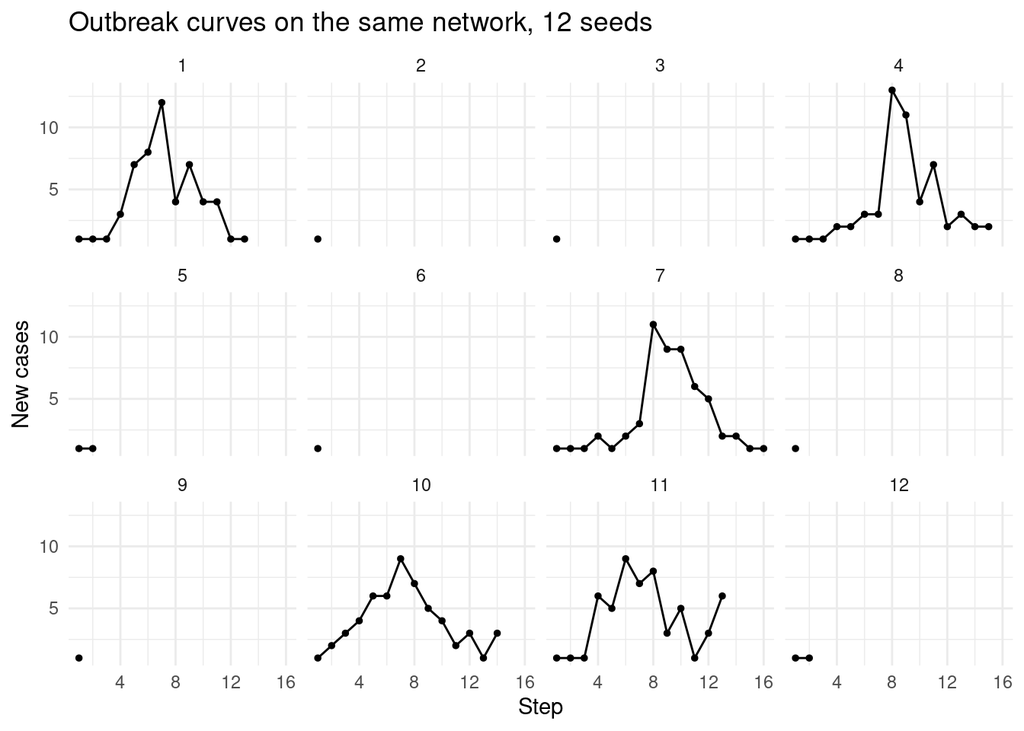

```r
run_many <- function(seeds, adj, p_infect = 0.3, max_steps = 15) {
  purrr_like <- lapply(seeds, function(s) {
    set.seed(s)
    curve <- simulate_on_network(adj, p_infect, max_steps)
    data.frame(seed = s, step = seq_along(curve), new_cases = curve)
  })
  do.call(rbind, purrr_like)
}

seeds <- 1:12
sim_runs <- run_many(seeds, adj)

ggplot(sim_runs, aes(step, new_cases)) +
  geom_line() + geom_point(size = 1) +
  facet_wrap(~ seed) +
  labs(title = "Outbreak curves on the same network, 12 seeds",
       x = "Step", y = "New cases") +
  theme_minimal()
```

Yes: with `adj`, `p_infect`, and `max_steps` all held fixed, different seeds still produce very different outcomes. Some runs fizzle out after one or two steps (the randomly-chosen starting node happens to be low-degree or in a sparsely-connected part of the network), while others take off and infect a large share of the network before dying out. This is the network analogue of Week 5’s “many identical outbreaks look different” lesson: even with the process’s *rules* fixed, chance in *which* node starts the outbreak and *which* edges “fire” produces substantial run-to-run variability.

### Exercise 4.2 (extension) - Solution

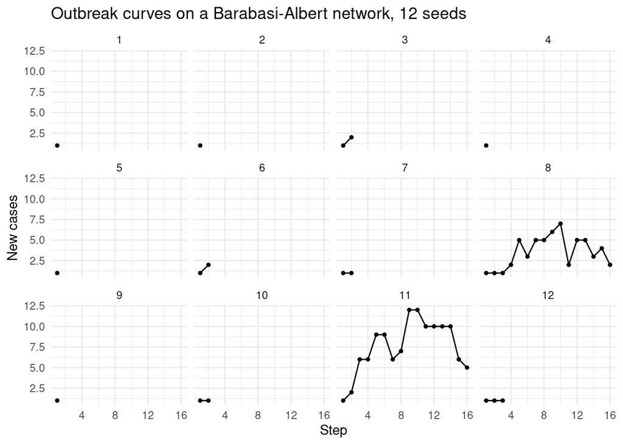

```r
set.seed(2026)
adj_ba <- as.matrix(igraph::as_adjacency_matrix(igraph::as.undirected(
  igraph::sample_pa(n = 150, power = 1, m = 1, directed = FALSE)
)))

sim_runs_ba <- run_many(1:12, adj_ba)

ggplot(sim_runs_ba, aes(step, new_cases)) +
  geom_line() + geom_point(size = 1) +
  facet_wrap(~ seed) +
  labs(title = "Outbreak curves on a Barabasi-Albert network, 12 seeds",
       x = "Step", y = "New cases") +
  theme_minimal()
```

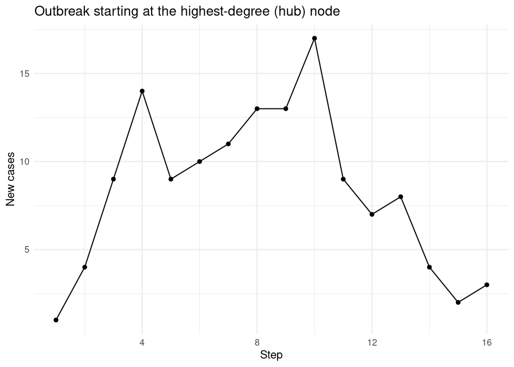

```r
# Starting deliberately at the highest-degree node instead of a random one
simulate_from_node <- function(adj, start, p_infect = 0.3, max_steps = 15) {
  n <- nrow(adj)
  infected <- rep(FALSE, n); infected[start] <- TRUE
  new_cases <- sum(infected)
  for (t in 1:max_steps) {
    current <- which(infected)
    candidates <- which(!infected)
    would_infect <- sapply(candidates, function(j) {
      neighbours_infected <- sum(adj[j, current] == 1)
      runif(1) < 1 - (1 - p_infect)^neighbours_infected
    })
    newly <- candidates[would_infect]
    if (length(newly) == 0) break
    infected[newly] <- TRUE
    new_cases <- c(new_cases, length(newly))
  }
  new_cases
}

hub_node <- which.max(igraph::degree(igraph::graph_from_adjacency_matrix(
  adj_ba, mode = "undirected")))

set.seed(2026)
curve_hub <- simulate_from_node(adj_ba, start = hub_node)

ggplot(data.frame(step = seq_along(curve_hub), new_cases = curve_hub),
       aes(step, new_cases)) +
  geom_line() + geom_point() +
  labs(title = "Outbreak starting at the highest-degree (hub) node",
       x = "Step", y = "New cases") +
  theme_minimal()
```

Outbreaks on the Barabási-Albert network typically show more extreme, bimodal-looking variability across runs than on the Erdős-Rényi network: most random starting nodes are low-degree “leaves” and their outbreaks fizzle almost immediately, but the rare run that happens to start at (or quickly reach) a hub takes off explosively. Deliberately starting at the highest-degree node removes that randomness and reliably produces one of the larger, faster-growing outbreaks, because the hub’s many simultaneous neighbours give the infection many chances to spread in the very first step — directly illustrating why hub nodes are the natural priority targets for vaccination or surveillance, echoing the betweenness discussion in Exercise 2.2.

### Looking ahead to Week 8

Next week we add two new dimensions to networks: **space** (nodes have geographic coordinates, edges drawn on maps) and **time** (networks that evolve, e.g. epidemic spread). The representation/encoding choices worked through above (node-link vs matrix vs arc, attribute encodings) still apply, but they are now layered onto a basemap or a sequence of snapshots. The Tutorial 3 bootstrap code and the Tutorial 4 network-constrained branching process above are both direct inputs to Week 8’s capstone figure, which combines simulation (Week 5), uncertainty (Week 6), and network visualisation (Week 7) into a single multi-panel figure with space and time layered on top.

## Running seed log

| Location | Seed(s) used |
| --- | --- |
| 0.1 graph generation | `set.seed(2026)` |
| 0.1 layout / Ex 0.1 layouts | `set.seed(1)` |
| 0.2 graph generation | `set.seed(2026)` |
| 0.3 graph generation | `set.seed(2026)` |
| 1.3 layout / Ex 1.3 (`fr`, `kk`, `stress`) | `set.seed(1)` |
| Ex 1.4 comparison graph | `set.seed(2026)` |
| 2.2 layout / Ex 2.1 layouts | `set.seed(1)` |
| 2.4 layouts / Ex 2.3 layouts | `set.seed(1)` |
| Ex 3.4 bootstrap | `set.seed(2026)` |
| 4.1 graph + simulation | `set.seed(2026)` |
| Ex 4.1 (per-run seeds) | `1:12` |
| Ex 4.2 graph + simulation | `set.seed(2026)` |